# Laboratory Values Stats - PhysioNet Sepsis Challenge

efg | 2019-03-05

# 1 Purpose

The purpose of this notebook is to take a preliminary look at the raw data from 5000 patients in the PhysioNet 2019 challenge, where some had sepsis and some did not.

The focus of this notebook is on the **Laboratory Values** data (**columns 9 - 34**) and the outcome (column 41)

- `SepsisLabel`. For sepsis patients, `SepsisLabel` is 1 if $t \ge t_{sepsis} - 6$ and 0 if $t < t_{sepsis} - 6$. For non-sepsis patients, `SepsisLabel` is 0.

# 2 Background

The data being analyzed is from the [Early Prediction of Sepsis from Clinical Data: the PhysioNet/Computing in Cardiology Challenge 2019](https://physionet.org/challenge/2019/).

# 3 Exploration

## 3.1 Setup

```r
plotCaptionLeft  <- "Source:  PhysioNet 2019 Sepsis Project"
plotCaptionRight <- paste("efg", format(Sys.time(), "%Y-%m-%d"))
```

### 3.1.1 Packages

```r
library(tidyverse)
library(kableExtra) # kable_styling
library(readxl)
library(gridExtra)
library(grid)
```

### 3.1.2 Helper function

```r
Show <- function(data, caption="", bigMark="")
{
  data                                          %>%
  kable("html",
        caption=caption,
        format.args = list(big.mark=bigMark))   %>%
  kable_styling(bootstrap_options = c("striped", "bordered", "condensed"),
                position = "left", full_width = FALSE)
}
```

### 3.1.3 Laboratory Values List and Units

Quantity

Units

Description

Alkalinephos

IU/L

Alkaline phosphatase

AST

IU/L

Aspartate transaminase

BaseExcess

mmol/L

Measure of excess bicarbonate

Bilirubin_direct

mg/dL

Bilirubin direct

Bilirubin_total

mg/dL

Total bilirubin

BUN

mg/dL

Blood urea nitrogen

Calcium

mg/dL

Calcium

Chloride

mmol/L

Chloride

Creatinine

mg/dL

Creatinine

Fibrinogen

mg/dL

Fibrinogen

FiO2

%

Fraction of inspired oxygen

Glucose

mg/dL

Serum glucose

HCO3

mmol/L

Bicarbonate

Hct

%

Hematocrit

Hgb

g/dL

Hemoglobin

Lactate

mg/dL

Lactic acid

Magnesium

mmol/dL

Magnesium

PaCO2

mm Hg

Partial pressure of carbon dioxide from arterial blood

pH

Measure of acidity or basicity

Phosphate

mg/dL

Phosphate

Platelets

count/mL

Platelets

Potassium

mmol/L

Potassium

PTT

seconds

partial thromboplastin time

SaO2

%

Oxygen saturation from arterial blood

TroponinI

ng/mL

Troponinl

WBC

count/L

Leukocyte count

The lab values are sorted here by Quantity name, which is a different order than in the file.

### 3.1.4 Load PhysioNet 2019 Challenge Combined Data

```r
load(file = "../../data/PhysioNet-2019-Raw-Data.RData")
dim(allData)
```

```
[1] 188453     42
```

Verify Laboratory Values match

```r
all(labValues$Quantity %in% names(allData))
```

```
[1] TRUE
```

Sample Laboratory Values

```r
allData                                           %>%
  select( patient, ICULOS,
          labValues$Quantity,
          SepsisLabel)                            %>%
  head()                                          %>%
  Show()
```

| patient | ICULOS | Alkalinephos | AST | BaseExcess | Bilirubin_direct | Bilirubin_total | BUN | Calcium | Chloride | Creatinine | Fibrinogen | FiO2 | Glucose | HCO3 | Hct | Hgb | Lactate | Magnesium | PaCO2 | pH | Phosphate | Platelets | Potassium | PTT | SaO2 | TroponinI | WBC | SepsisLabel |
| --- | --- | --- | --- | --- | --- | --- | --- | --- | --- | --- | --- | --- | --- | --- | --- | --- | --- | --- | --- | --- | --- | --- | --- | --- | --- | --- | --- | --- |
| p00001 | 1 | NaN | NaN | NaN | NaN | NaN | NaN | NaN | NaN | NaN | NaN | NaN | NaN | NaN | NaN | NaN | NaN | NaN | NaN | NaN | NaN | NaN | NaN | NaN | NaN | NaN | NaN | 0 |
| p00001 | 2 | NaN | NaN | NaN | NaN | NaN | NaN | NaN | NaN | NaN | NaN | NaN | NaN | NaN | NaN | NaN | NaN | NaN | NaN | NaN | NaN | NaN | NaN | NaN | NaN | NaN | NaN | 0 |
| p00001 | 3 | NaN | NaN | NaN | NaN | NaN | NaN | NaN | NaN | NaN | NaN | NaN | 233 | NaN | NaN | NaN | NaN | NaN | NaN | NaN | NaN | NaN | NaN | NaN | NaN | NaN | NaN | 0 |
| p00001 | 4 | NaN | NaN | NaN | NaN | NaN | NaN | NaN | NaN | NaN | NaN | NaN | NaN | NaN | NaN | NaN | NaN | NaN | NaN | NaN | NaN | NaN | NaN | NaN | NaN | NaN | NaN | 0 |
| p00001 | 5 | NaN | NaN | NaN | NaN | NaN | NaN | NaN | NaN | NaN | NaN | NaN | NaN | NaN | NaN | NaN | NaN | NaN | NaN | NaN | NaN | NaN | NaN | NaN | NaN | NaN | NaN | 0 |
| p00001 | 6 | NaN | NaN | NaN | NaN | NaN | NaN | NaN | NaN | NaN | NaN | NaN | NaN | NaN | NaN | NaN | NaN | NaN | NaN | NaN | NaN | NaN | NaN | NaN | NaN | NaN | NaN | 0 |

## 3.2 Sepsis Label

```r
table(allData$SepsisLabel, useNA = "ifany")
```

```
     0      1
185830   2623
```

## 3.3 Laboratory Values

```r
for (i in 1:nrow(labValues))
{
  cat("\n###", paste(labValues$Quantity[i], " - ",
                     labValues$Description[i]), "\n")

  rawData <-
    allData                                      %>%
    select(labValues$Quantity[i], SepsisLabel)   %>%
    na.omit()                                    %>%
    mutate(Sepsis = recode(SepsisLabel,
                           "0" = "Not Sepsis",
                           "1" = "Sepsis"))      %>%
    mutate(Sepsis = as.factor(Sepsis))

  if (labValues$Units[i] == "-")
  {
    quantityUnits <- ""    # display no units
  } else
  {
    quantityUnits <- paste0("[", labValues$Units[i], "]")
  }

  valueBoxplot <-
    ggplot(rawData,
           aes_string("Sepsis",
                      labValues$Quantity[i],
                      fill = "Sepsis"))                       +
    geom_boxplot(notch = TRUE)                                +
    scale_x_discrete(labels = paste(c("Not Sepsis", "Sepsis"),
                                    paste0("n = ",
                                           table(rawData$Sepsis)) ,
                                    sep = "\n") )             +
    labs(title = paste(labValues$Quantity[i], " - ",
                       labValues$Description[i]),
         x = "",
         y = paste0(labValues$Quantity[i], quantityUnits))    +
    scale_fill_brewer(palette = "Pastel1", direction = -1)    +
    theme(legend.position = "none",
          plot.margin = unit(c(5, 5, 5, 12), "mm"))           +
    coord_flip()

  valueDensity <-
    ggplot(rawData, aes_string(x = labValues$Quantity[i]))    +
    geom_density(aes_string(group = "Sepsis", fill = "Sepsis"),
                 alpha = 0.5)   +
    labs(x = paste0(labValues$Quantity[i], quantityUnits),
         caption = c(plotCaptionLeft, plotCaptionRight))      +
    scale_fill_brewer(palette = "Pastel1", direction = -1)    +
    theme(plot.caption = element_text(hjust = c(0, 1)),
          legend.position = "none",
          plot.margin = unit(c(5, 5, 5, 20), "mm"))

  grid.arrange(valueBoxplot, valueDensity)

  cat("\n")
}
```

### 3.3.1 Alkalinephos - Alkaline phosphatase

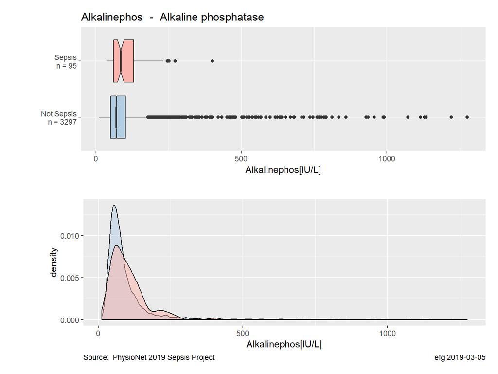

### 3.3.2 AST - Aspartate transaminase

```
## notch went outside hinges. Try setting notch=FALSE.
```

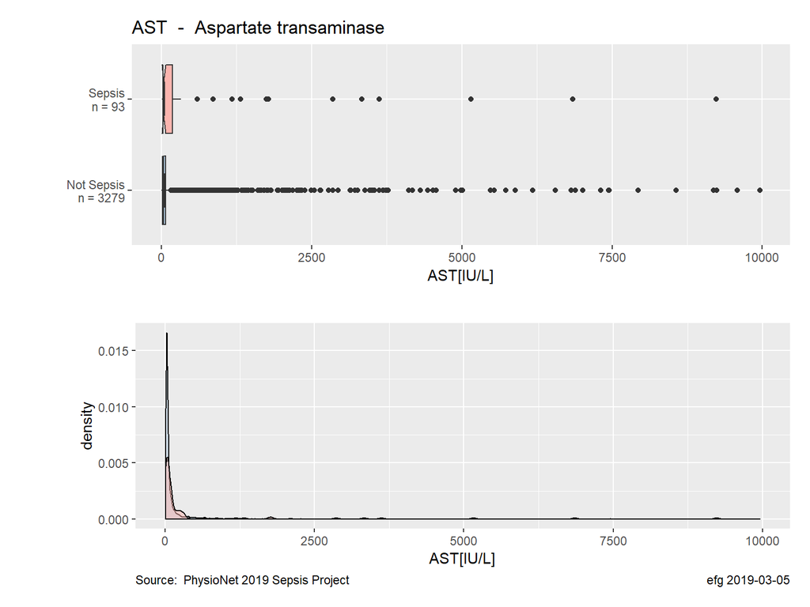

### 3.3.3 BaseExcess - Measure of excess bicarbonate

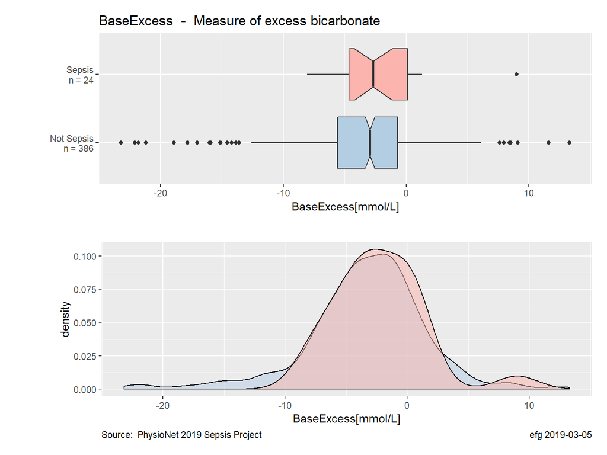

### 3.3.4 Bilirubin_direct - Bilirubin direct

```
## notch went outside hinges. Try setting notch=FALSE.
```

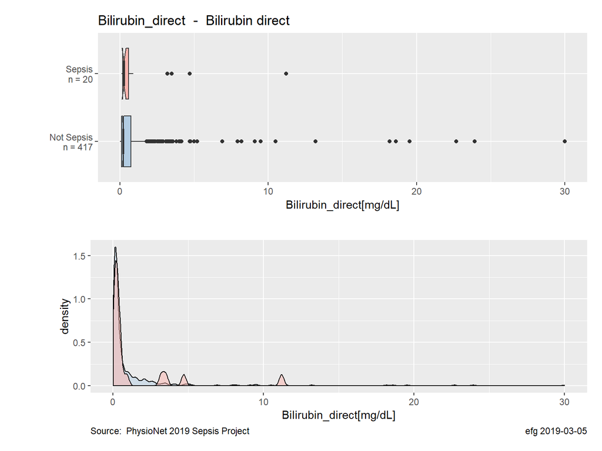

### 3.3.5 Bilirubin_total - Total bilirubin

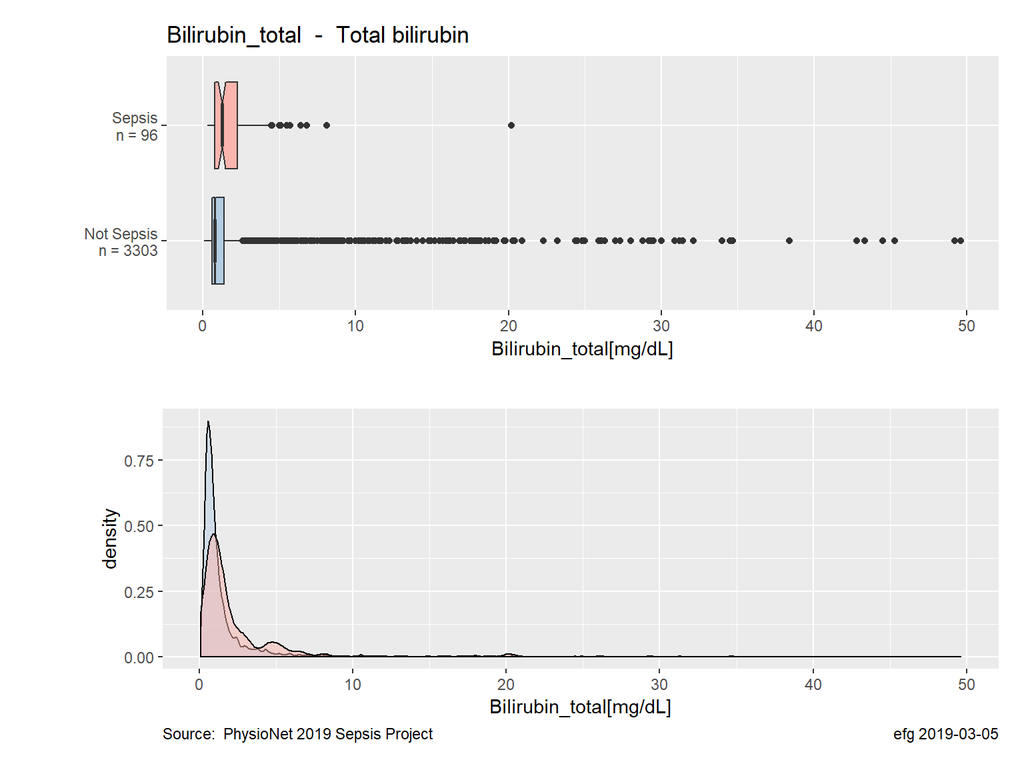

### 3.3.6 BUN - Blood urea nitrogen

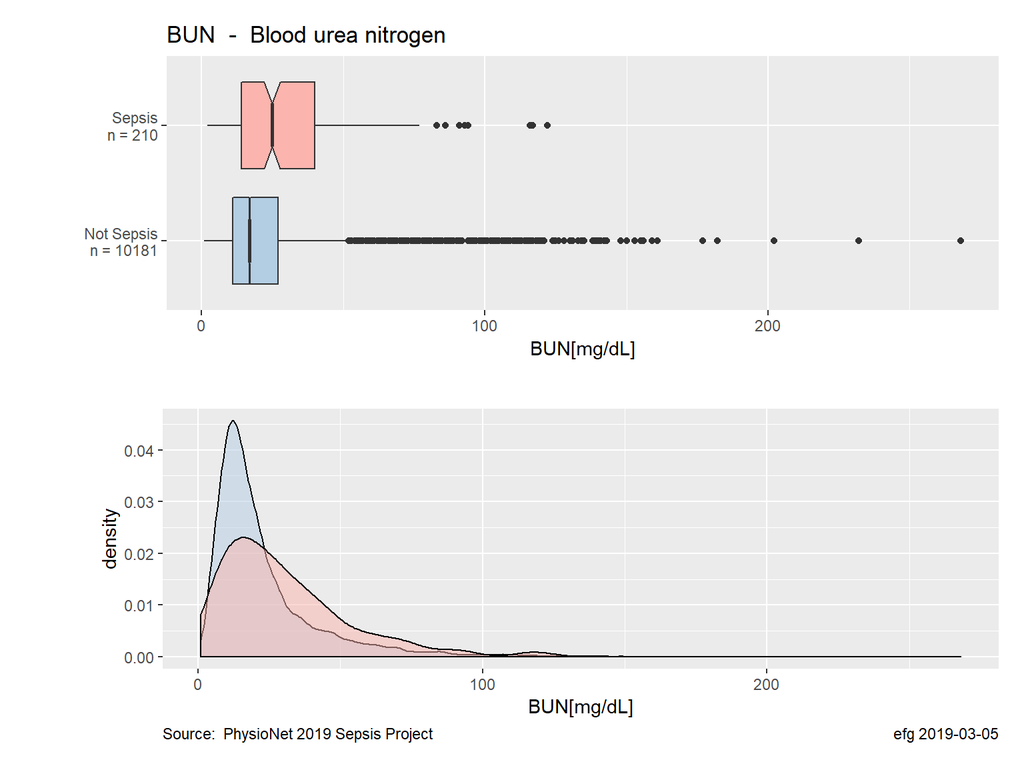

### 3.3.7 Calcium - Calcium

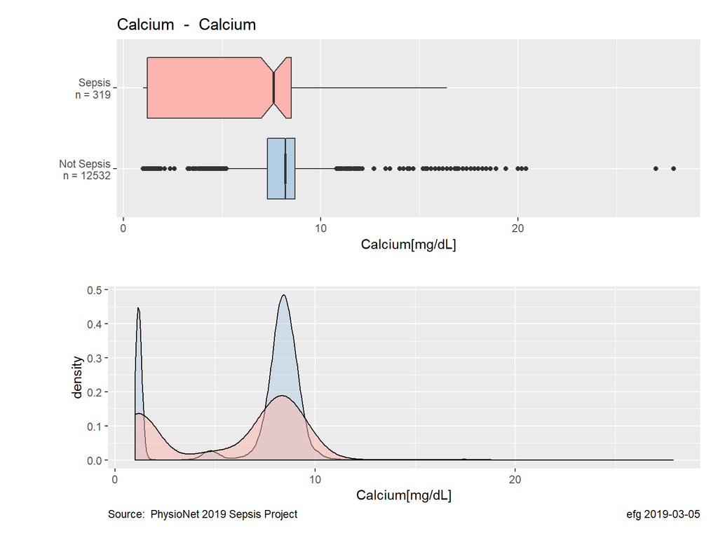

### 3.3.8 Chloride - Chloride

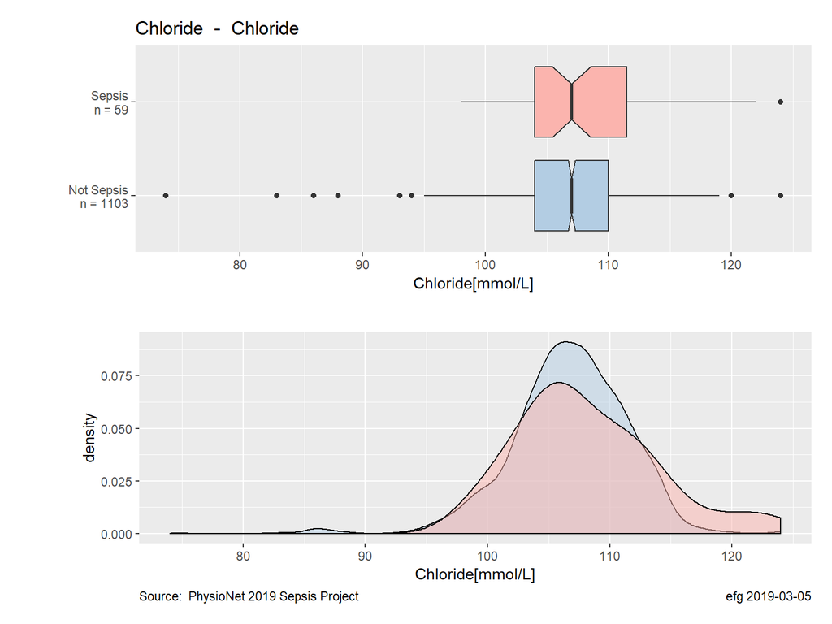

### 3.3.9 Creatinine - Creatinine

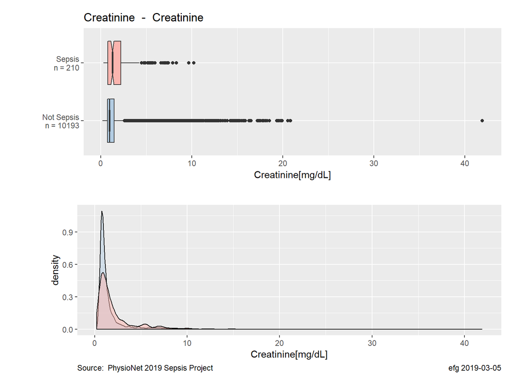

### 3.3.10 Fibrinogen - Fibrinogen

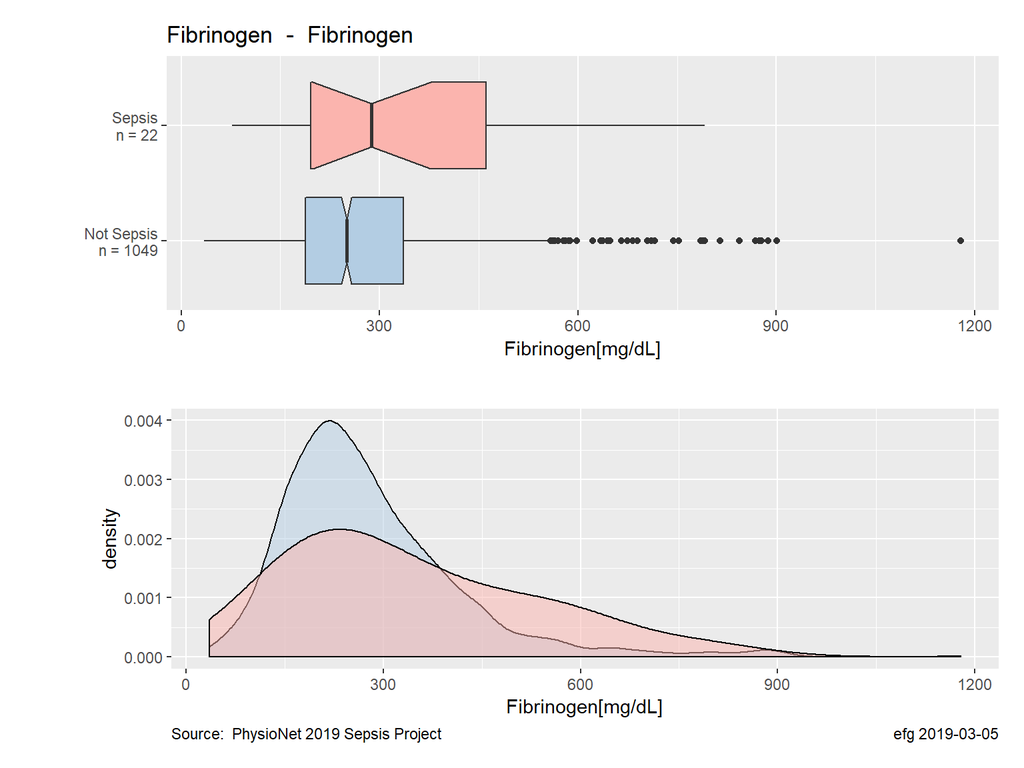

### 3.3.11 FiO2 - Fraction of inspired oxygen

```
## notch went outside hinges. Try setting notch=FALSE.
```

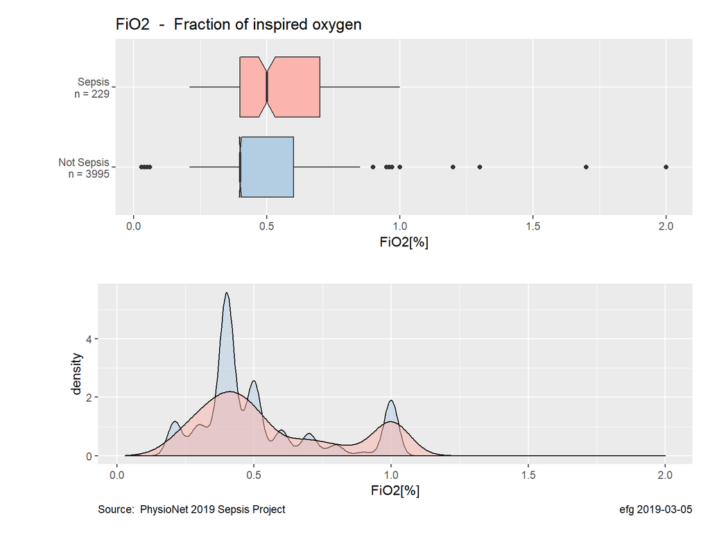

### 3.3.12 Glucose - Serum glucose

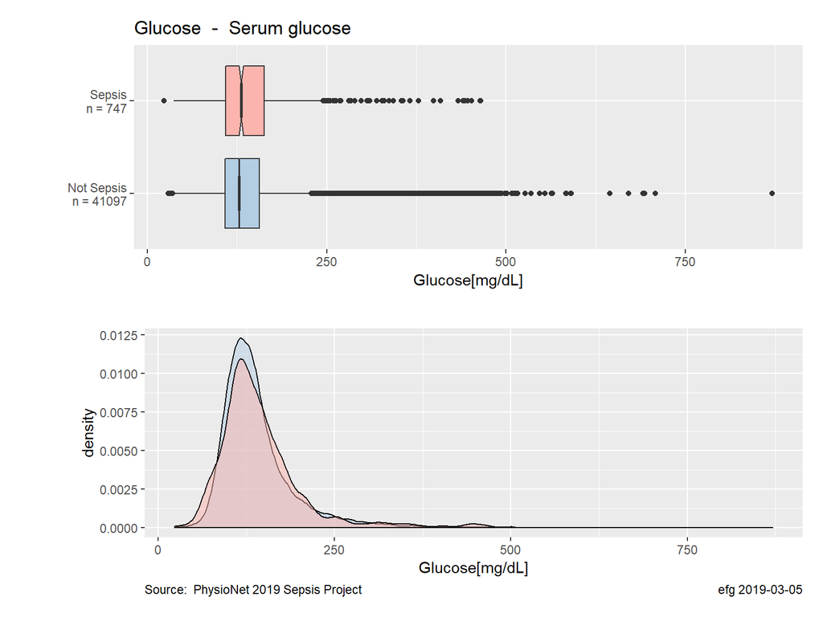

### 3.3.13 HCO3 - Bicarbonate

```
## notch went outside hinges. Try setting notch=FALSE.
```

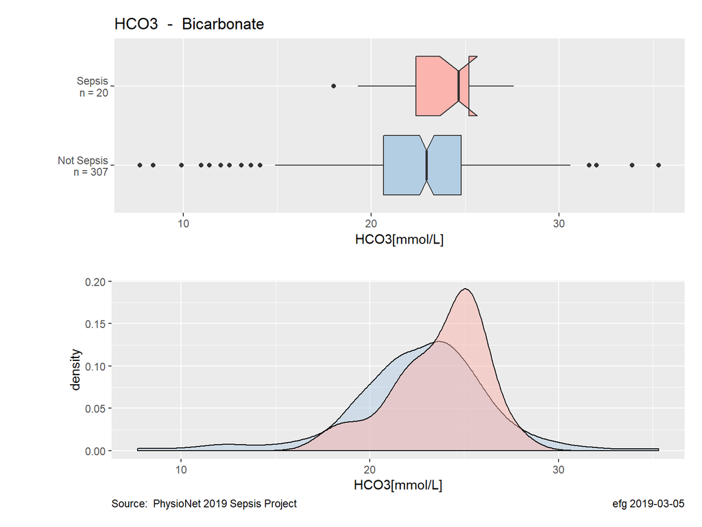

### 3.3.14 Hct - Hematocrit

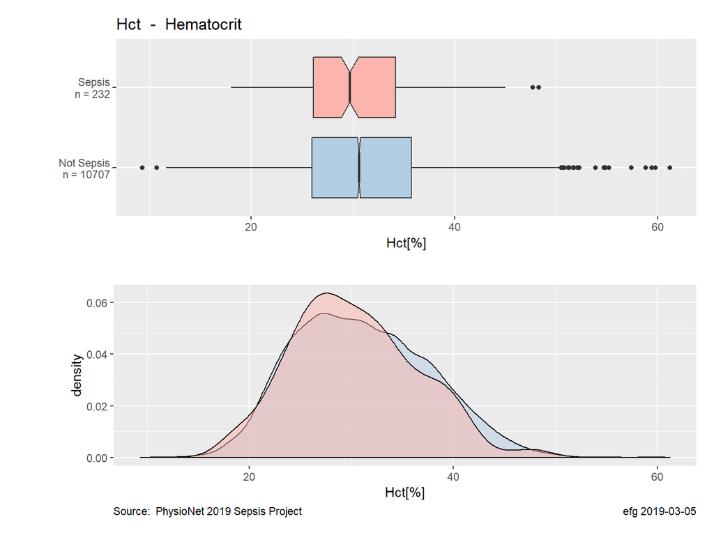

### 3.3.15 Hgb - Hemoglobin

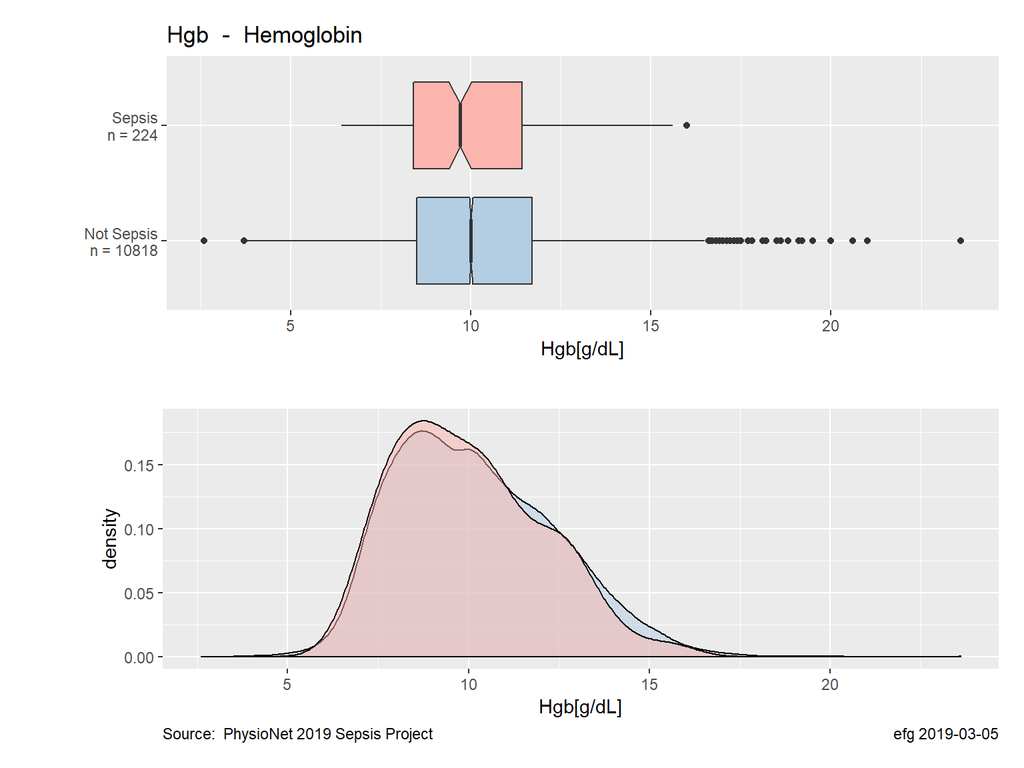

### 3.3.16 Lactate - Lactic acid

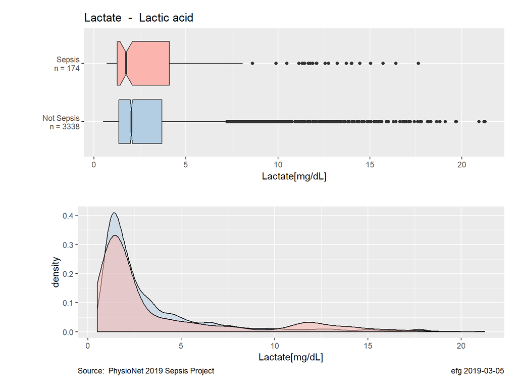

### 3.3.17 Magnesium - Magnesium

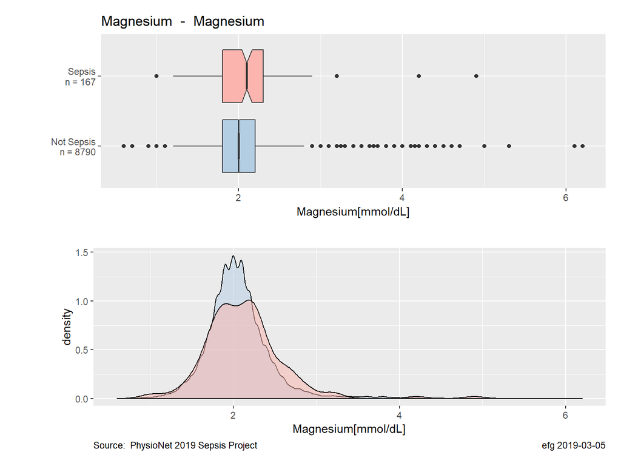

### 3.3.18 PaCO2 - Partial pressure of carbon dioxide from arterial blood

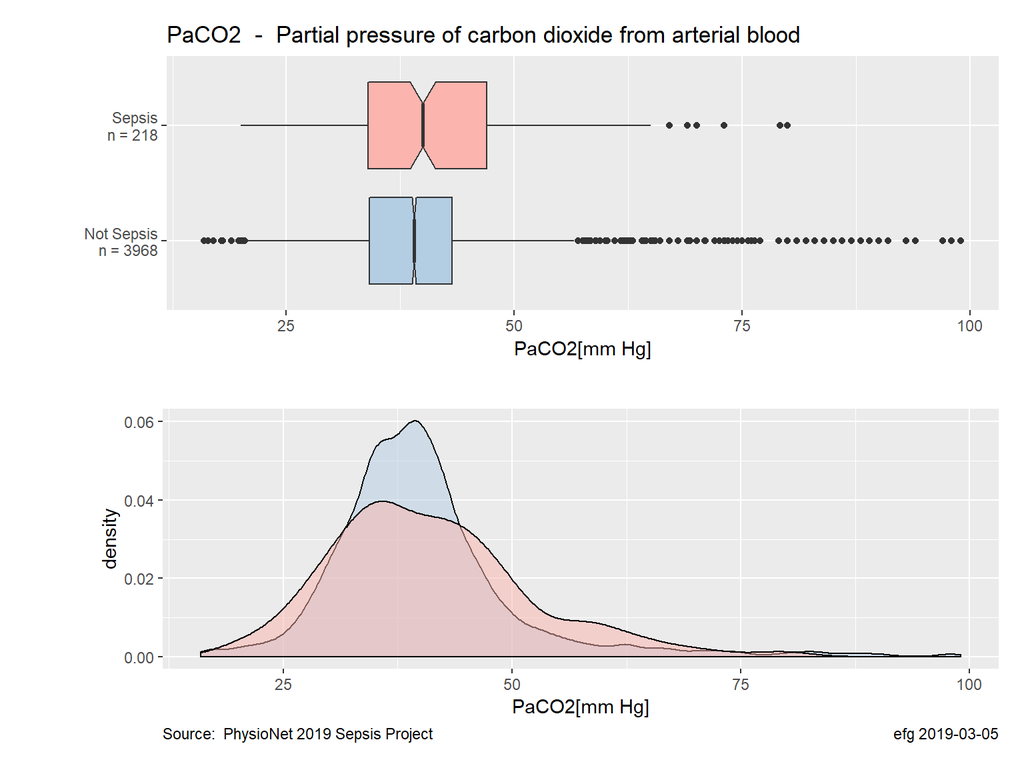

### 3.3.19 pH - Measure of acidity or basicity

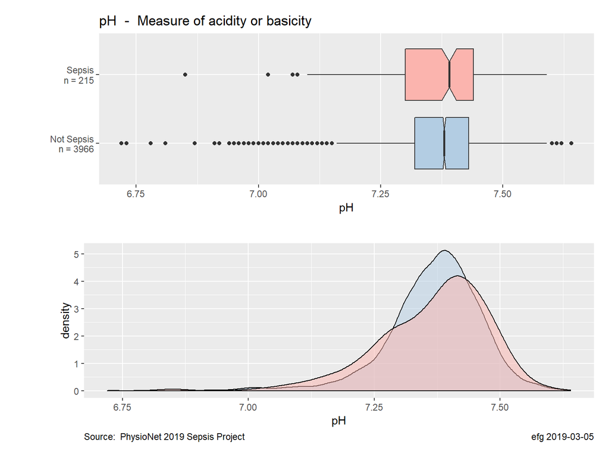

### 3.3.20 Phosphate - Phosphate

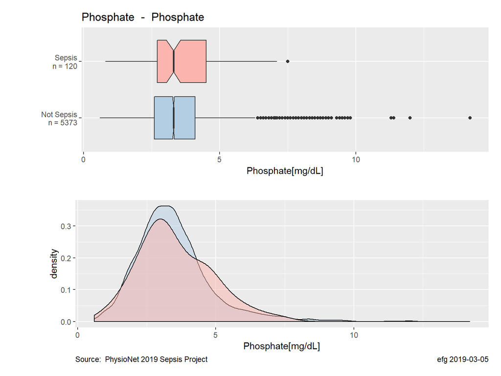

### 3.3.21 Platelets - Platelets

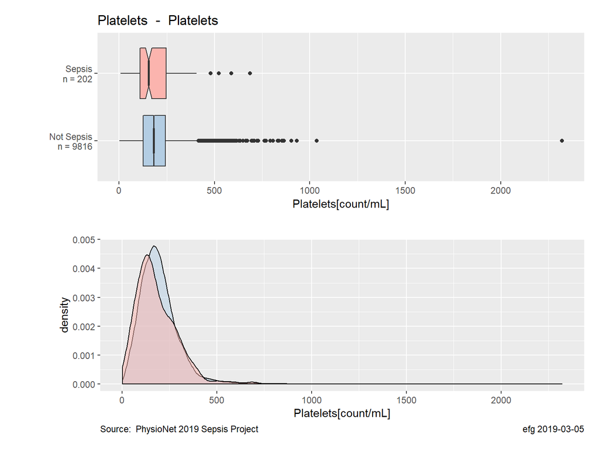

### 3.3.22 Potassium - Potassium

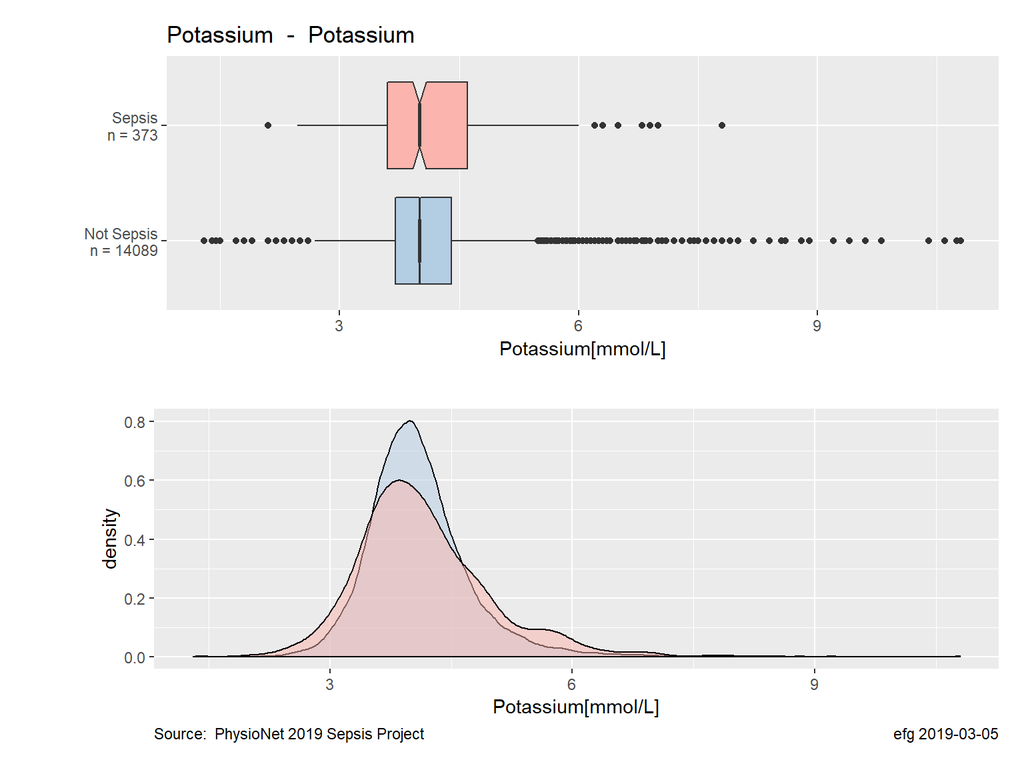

### 3.3.23 PTT - partial thromboplastin time

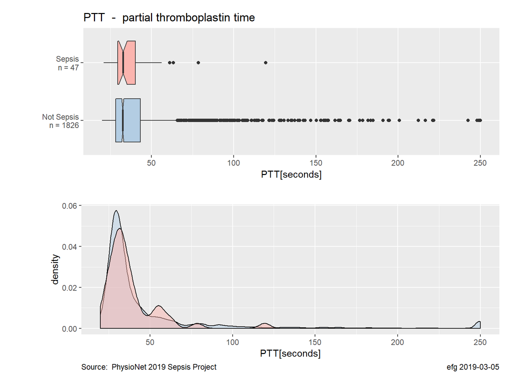

### 3.3.24 SaO2 - Oxygen saturation from arterial blood

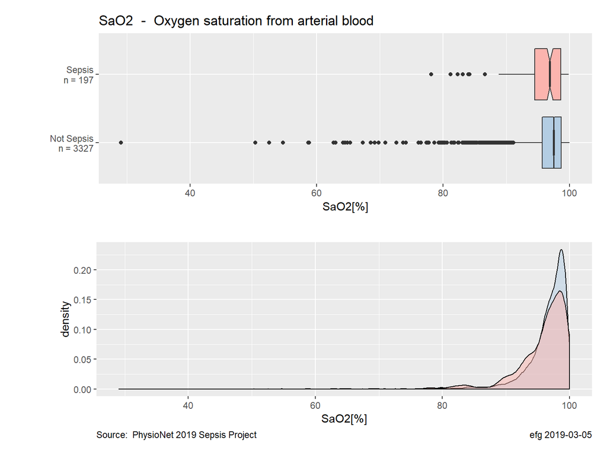

### 3.3.25 TroponinI - Troponinl

```
## notch went outside hinges. Try setting notch=FALSE.
```

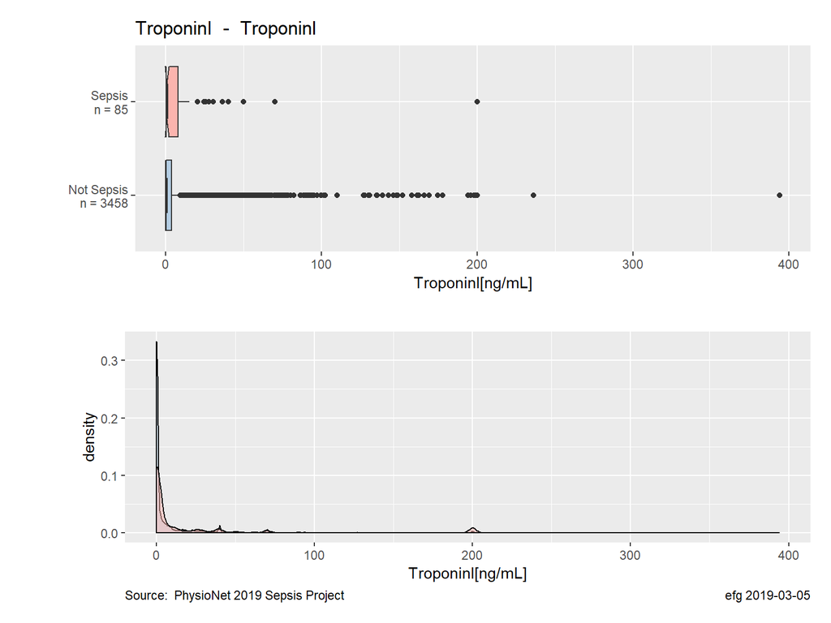

### 3.3.26 WBC - Leukocyte count

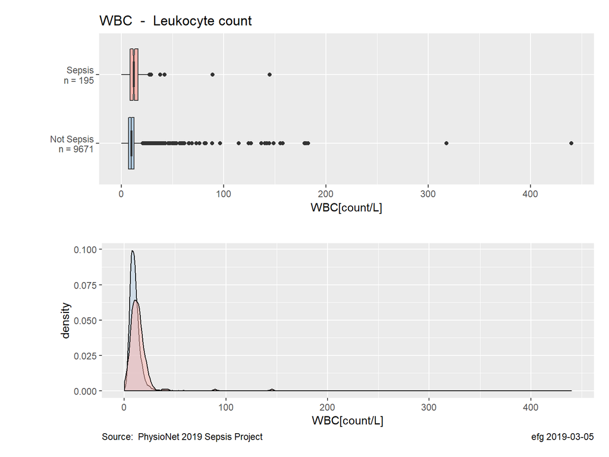

# 4 Discussion

[work in progress]

# 5 Conclusions

[work in progress]

Processing time: 20.9 secs

2019-03-05 2233